# 신용카드 고객이탈 분석

이은서

2022-02-03

# 신용카드 고객이탈분석 모델 개발

## 과제 목표

신용카드 이용 고객 데이터를 활용한 고객 이탈 예측 모델 개발

## 분석결과 활용 프로세스

고객 이탈에 있어 어떠한 요소가 크게 작용하는지 분석 후 고객 이탈 방지

## 현황

신규 고객 유입보다는 기존 고객의 이탈을 방지함으로써 고객 수 유지 필요

## 문제점

이탈 고객 분류가 제대로 이루어지지 않아 이탈 가능성이 있는 고객을 제대로 구분해내지 못하는 중

## 분석 주요 내용

1. 이탈 / 비이탈 고객 분류
2. 사용카드 선택에 있어 가장 많은 영향을 끼치는 고객 특성 선정
3. 결과 도출

## 기대효과

- 기존에 분류하지 못했던 숨은 이탈 고객을 분류하여 분류 원인 발견 가능
- 이탈 가능성이 있는 고객의 상황과 이탈 이유를 분석하여 향상된 고객서비스 제공
- 다양한 카드 서비스 제공을 위한 고객 특성 분석 및 희망 서비스 예측 가능

## 필요 데이터

신용카드 고객 데이터

## 1. 분석 데이터 구성

```
##  [1] "Customer_Age"             "Gender"
##  [3] "Dependent_count"          "Education_Level"
##  [5] "Marital_Status"           "Income_Category"
##  [7] "Card_Category"            "Months_on_book"
##  [9] "Total_Relationship_Count" "Months_Inactive_12_mon"
## [11] "Contacts_Count_12_mon"    "Credit_Limit"
## [13] "Total_Revolving_Bal"      "Avg_Open_To_Buy"
## [15] "Total_Amt_Chng_Q4_Q1"     "Total_Trans_Amt"
## [17] "Total_Trans_Ct"           "Total_Ct_Chng_Q4_Q1"
## [19] "Avg_Utilization_Ratio"    "label"
```

- 데이터 명세

```
##   Customer_Age Gender Dependent_count Education_Level Marital_Status
## 1           45      M               3     High School        Married
## 2           49      F               5        Graduate         Single
## 3           51      M               3        Graduate        Married
## 4           40      F               4     High School        Unknown
## 5           40      M               3      Uneducated        Married
## 6           44      M               2        Graduate        Married
##   Income_Category Card_Category Months_on_book Total_Relationship_Count
## 1     $60K - $80K          Blue             39                        5
## 2  Less than $40K          Blue             44                        6
## 3    $80K - $120K          Blue             36                        4
## 4  Less than $40K          Blue             34                        3
## 5     $60K - $80K          Blue             21                        5
## 6     $40K - $60K          Blue             36                        3
##   Months_Inactive_12_mon Contacts_Count_12_mon Credit_Limit Total_Revolving_Bal
```

[output cut: 20 more lines]

## 2. EDA

## 데이터 기본통계

```
##   Customer_Age   Gender   Dependent_count      Education_Level  Marital_Status
##  Min.   :26.00   F:5358   Min.   :0.000   College      :1013   Married :4687
##  1st Qu.:41.00   M:4769   1st Qu.:1.000   Graduate     :3128   Single  :3943
##  Median :46.00            Median :2.000   High School  :2013   Divorced: 748
##  Mean   :46.33            Mean   :2.346   Post-Graduate: 516   Unknown : 749
##  3rd Qu.:52.00            3rd Qu.:3.000   Doctorate    : 451
##  Max.   :73.00            Max.   :5.000   Uneducated   :1487
##                                           Unknown      :1519
##        Income_Category  Card_Category  Months_on_book  Total_Relationship_Count
##  Less than $40K:3561   Blue    :9436   Min.   :13.00   Min.   :1.000
##  $40K - $60K   :1790   Silver  : 555   1st Qu.:31.00   1st Qu.:3.000
##  $60K - $80K   :1402   Gold    : 116   Median :36.00   Median :4.000
##  $80K - $120K  :1535   Platinum:  20   Mean   :35.93   Mean   :3.813
##  $120K +       : 727                   3rd Qu.:40.00   3rd Qu.:5.000
##  Unknown       :1112                   Max.   :56.00   Max.   :6.000
##
##  Months_Inactive_12_mon Contacts_Count_12_mon  Credit_Limit
##  Min.   :0.000          Min.   :0.000         Min.   : 1438
##  1st Qu.:2.000          1st Qu.:2.000         1st Qu.: 2555
##  Median :2.000          Median :2.000         Median : 4549
##  Mean   :2.341          Mean   :2.455         Mean   : 8632
##  3rd Qu.:3.000          3rd Qu.:3.000         3rd Qu.:11068
##  Max.   :6.000          Max.   :6.000         Max.   :34516
##
##  Total_Revolving_Bal Avg_Open_To_Buy Total_Amt_Chng_Q4_Q1 Total_Trans_Amt
##  Min.   :   0        Min.   :    3   Min.   :0.0000       Min.   :  510
##  1st Qu.: 359        1st Qu.: 1324   1st Qu.:0.6310       1st Qu.: 2156
##  Median :1276        Median : 3474   Median :0.7360       Median : 3899
##  Mean   :1163        Mean   : 7469   Mean   :0.7599       Mean   : 4404
##  3rd Qu.:1784        3rd Qu.: 9859   3rd Qu.:0.8590       3rd Qu.: 4741
##  Max.   :2517        Max.   :34516   Max.   :3.3970       Max.   :18484
##
##  Total_Trans_Ct   Total_Ct_Chng_Q4_Q1 Avg_Utilization_Ratio label
##  Min.   : 10.00   Min.   :0.0000      Min.   :0.0000        0:8500
##  1st Qu.: 45.00   1st Qu.:0.5820      1st Qu.:0.0230        1:1627
##  Median : 67.00   Median :0.7020      Median :0.1760
##  Mean   : 64.86   Mean   :0.7122      Mean   :0.2749
##  3rd Qu.: 81.00   3rd Qu.:0.8180      3rd Qu.:0.5030
##  Max.   :139.00   Max.   :3.7140      Max.   :0.9990
##
```

## 이탈/비이탈 고객 분석

| label | Freq |
| --- | --- |
| 0 | 8500 |
| 1 | 1627 |

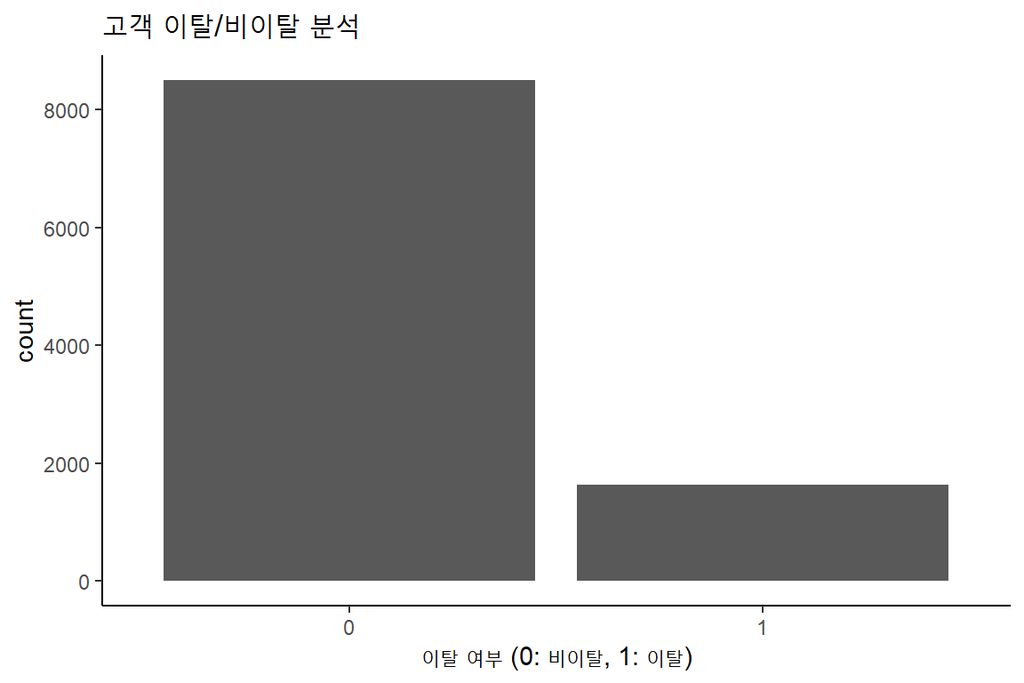

- 이탈 고객 1627명, 비이탈 고객 8500명, 전체 고객수의 16%가 이탈고객으로 데이터의 불균형이 보여짐 -> 이후 SMOTE를 통한 데이터 불균형 핸들링 진행

## 범주형 변수 분석

### 인구통계학적 특징 분석

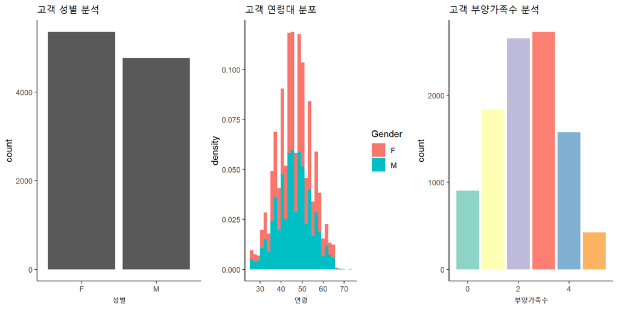

1. 여성 고객이 남성 고객보다 많음
2. 연령대는 20대부터 70대까지 골고루 분포, 가장 많은 연령대는 40대
3. 부양가족수는 평균 2.3명

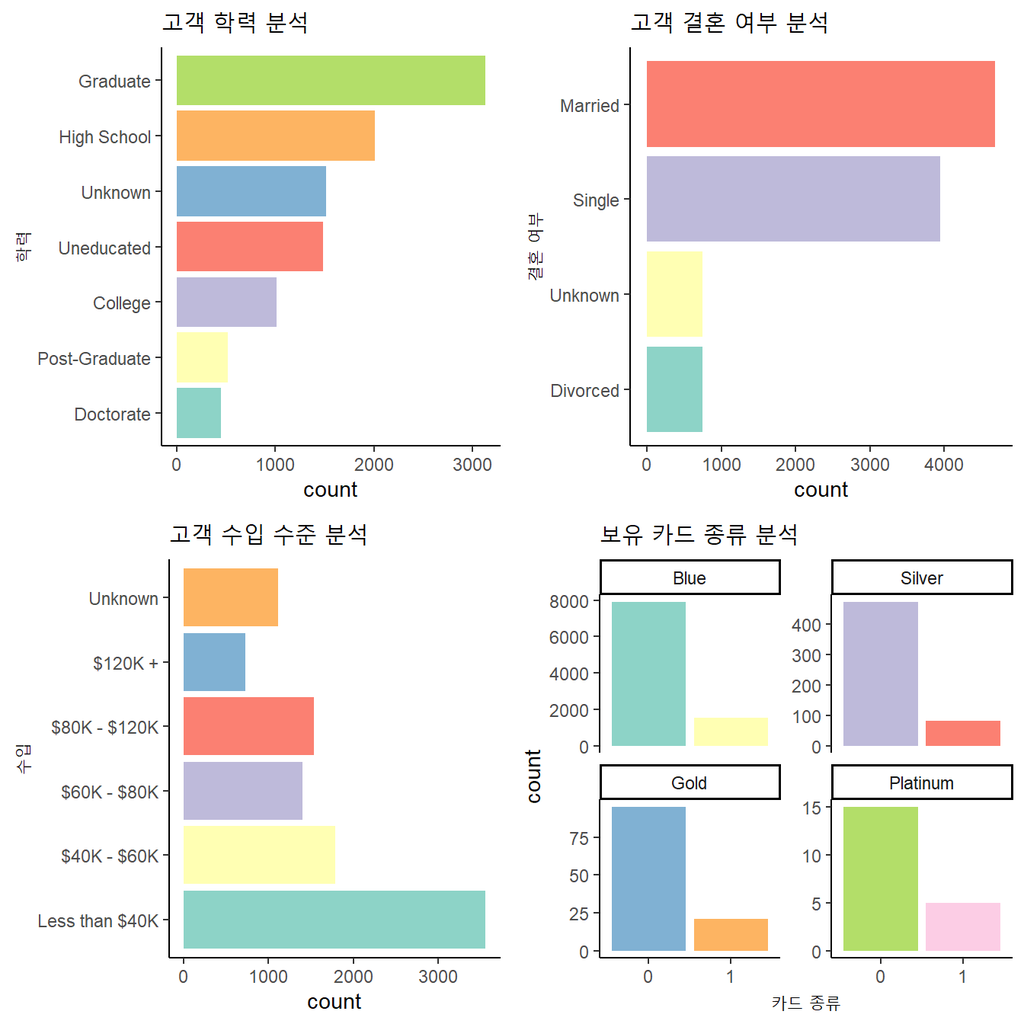

1. 고객의 학력은 대졸자가 가장 많음
2. 고객의 결혼 여부는 기혼이 가장 많음
3. 4만 달러 이하의 수입 수준의 고객 수가 가장 많음
4. 보유 카드 대비 플래티넘에서의 고객 이탈이 가장 많음음

### 수치형 변수 분석

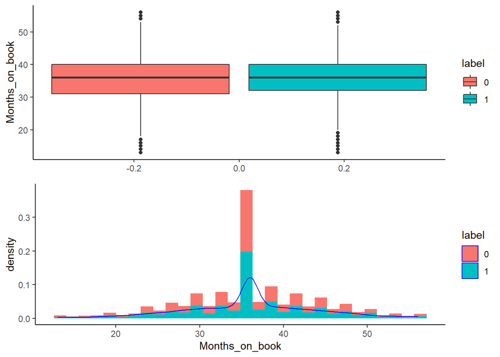

- 이탈 고객과 비이탈 고객의 은행 가입기간에는 큰 차이가 없음

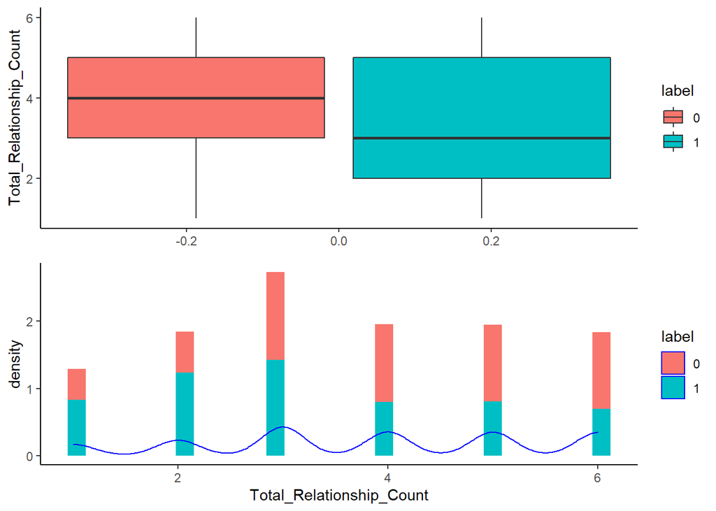

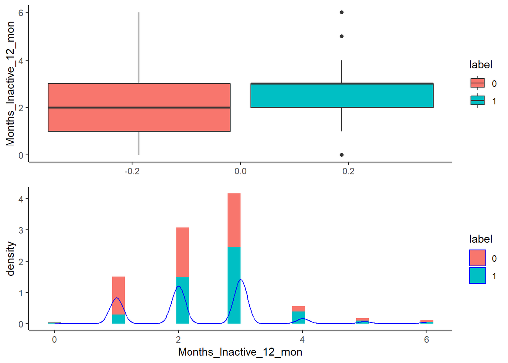

- 이탈 고객의 비활동(카드 비이용) 기간은 비이탈 고객보다 긺

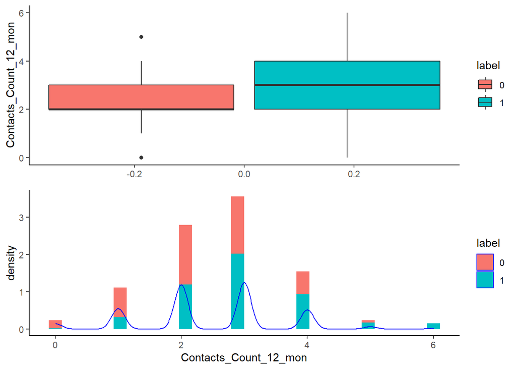

- 이탈 고객의 카드 이용 중 카드사 연락 횟수가 비이탈 고객보다 많음

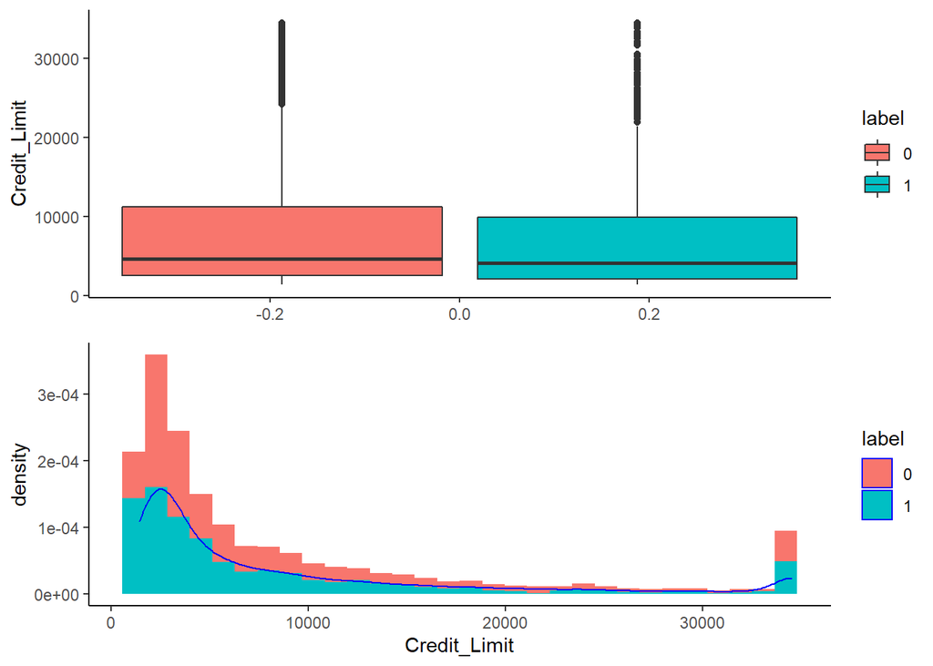

- 이탈 고객의 카드 이용 한도가 비이탈 고객보다 낮음

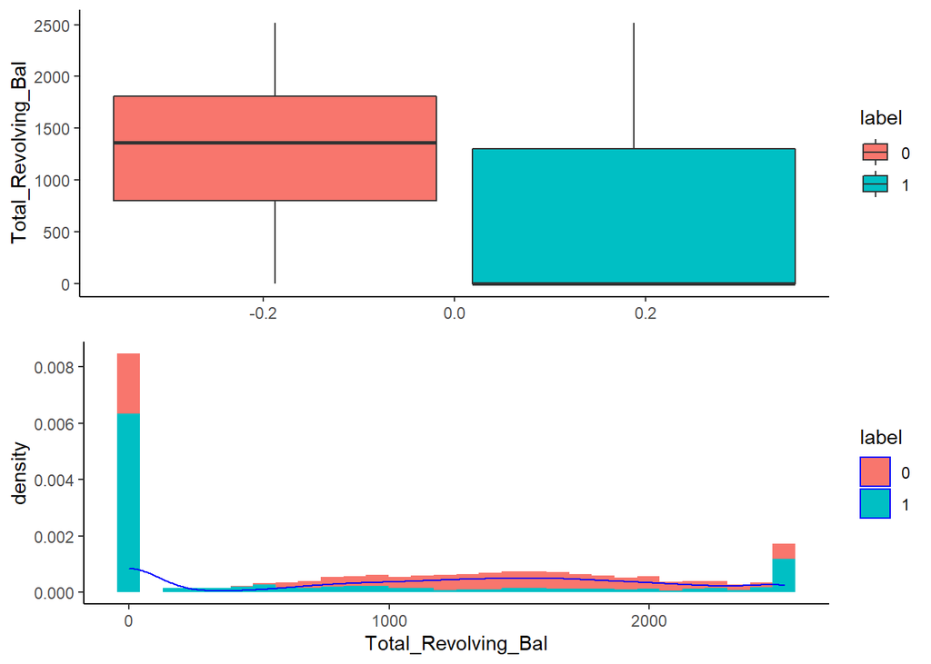

- 이탈 고객의 리볼빙 한도가 비이탈 고객보다 낮음

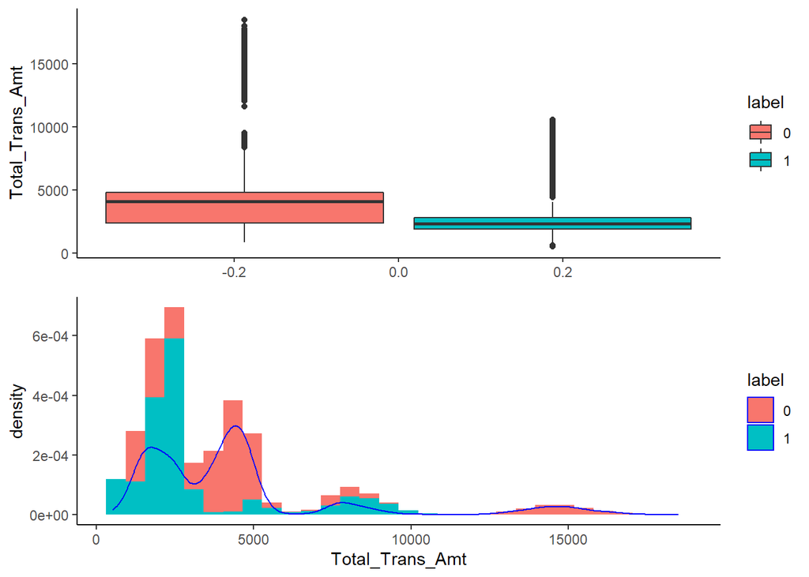

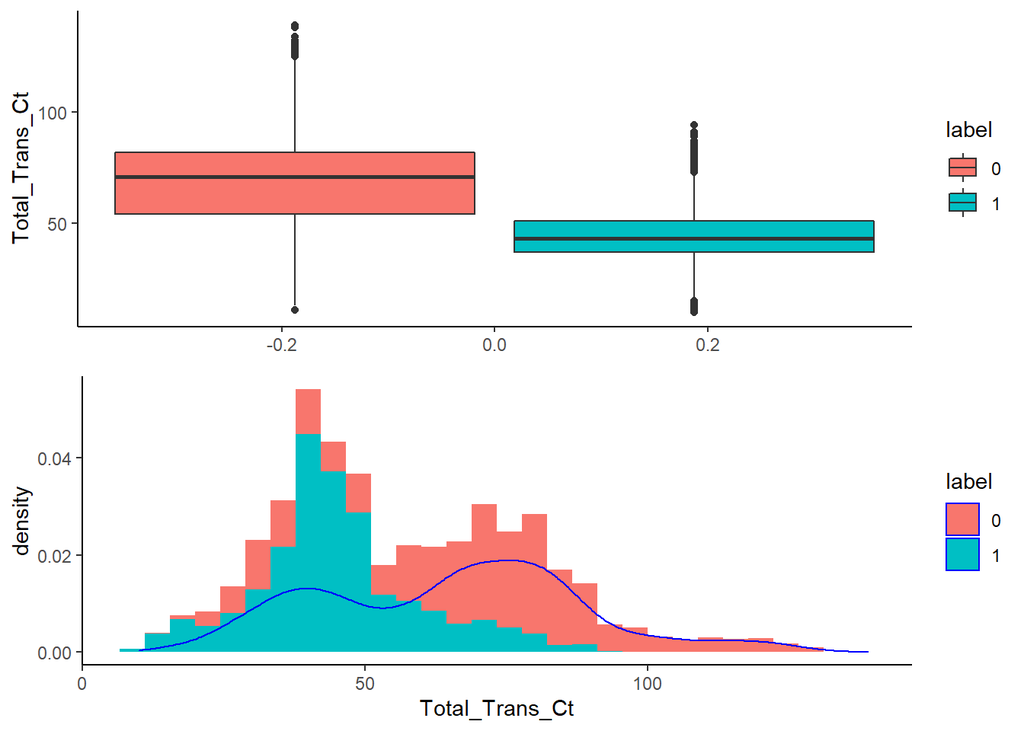

- 이탈 고객의 총 결제량과 횟수가 비이탈 고객보다 적음

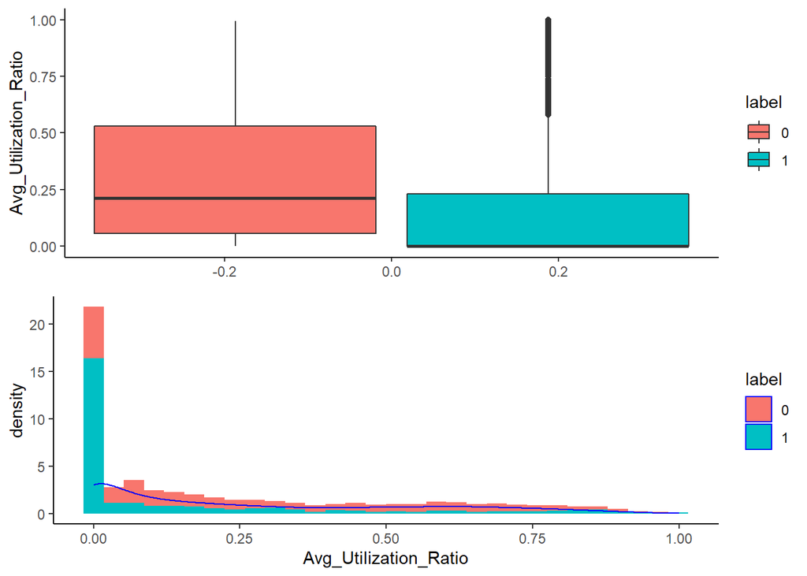

- 이탈 고객의 평균 카드 활용 비율이 비이탈 고객보다 적음

## 3. 변수간 상관관계

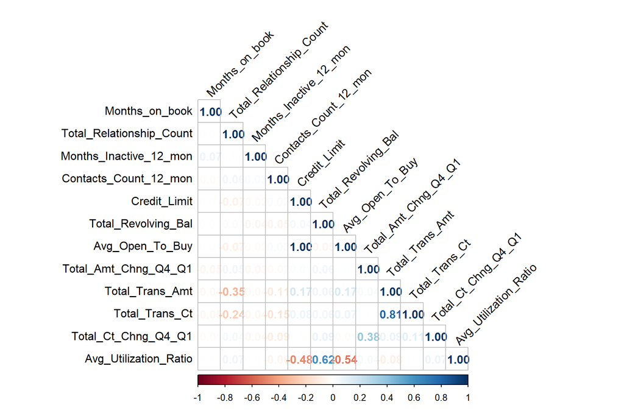

## 4. 분석 모델 개발

### 1. 데이터 불균형 처리 및 분할

```r
# 라벨인코딩
df$Gender <- as.numeric(df$Gender)
df$Education_Level <- as.numeric(df$Education_Level)
df$Marital_Status <- as.numeric(df$Marital_Status)
df$Income_Category <- as.numeric(df$Income_Category)
df$Card_Category <- as.numeric(df$Card_Category)

# 데이터 분할 (7:3)
df <- mutate_all(df, function(x) as.numeric(as.character(x)))
trainIndex <- createDataPartition(df$label, p = 0.70, list = F)
train <- df[trainIndex,]
test <- df[-trainIndex,]
```

```r
# SMOTE를 이용한 데이터 불균형 처리
train.smote <- SMOTE(train[1:19], train$label, K=5)
train.smote <- train.smote$data
train.smote$class<-factor(train.smote$class)
```

### 2. 분류 모델링 및 평가

#### 로지스틱 회귀모형

```r
library(e1071)
model1= glm(class ~., data=train.smote, family = "binomial")
step(model1, direction = "backward")
```

```
## Start:  AIC=7658.04
## class ~ Customer_Age + Gender + Dependent_count + Education_Level +
##     Marital_Status + Income_Category + Card_Category + Months_on_book +
##     Total_Relationship_Count + Months_Inactive_12_mon + Contacts_Count_12_mon +
##     Credit_Limit + Total_Revolving_Bal + Avg_Open_To_Buy + Total_Amt_Chng_Q4_Q1 +
##     Total_Trans_Amt + Total_Trans_Ct + Total_Ct_Chng_Q4_Q1 +
##     Avg_Utilization_Ratio
##
##
## Step:  AIC=7658.04
## class ~ Customer_Age + Gender + Dependent_count + Education_Level +
##     Marital_Status + Income_Category + Card_Category + Months_on_book +
##     Total_Relationship_Count + Months_Inactive_12_mon + Contacts_Count_12_mon +
##     Credit_Limit + Total_Revolving_Bal + Total_Amt_Chng_Q4_Q1 +
##     Total_Trans_Amt + Total_Trans_Ct + Total_Ct_Chng_Q4_Q1 +
##     Avg_Utilization_Ratio
##
##                            Df Deviance     AIC
## - Credit_Limit              1   7620.0  7656.0
## - Months_on_book            1   7620.0  7656.0
## - Avg_Utilization_Ratio     1   7620.2  7656.2
## - Customer_Age              1   7621.0  7657.0
## - Income_Category           1   7621.6  7657.6
## <none>                          7620.0  7658.0
## - Education_Level           1   7622.9  7658.9
## - Dependent_count           1   7629.3  7665.3
## - Card_Category             1   7634.8  7670.8
## - Total_Amt_Chng_Q4_Q1      1   7636.2  7672.2
## - Marital_Status            1   7652.9  7688.9
## - Gender                    1   7735.0  7771.0
## - Total_Revolving_Bal       1   7939.5  7975.5
## - Months_Inactive_12_mon    1   7972.4  8008.4
## - Contacts_Count_12_mon     1   8055.3  8091.3
## - Total_Relationship_Count  1   8073.6  8109.6
## - Total_Ct_Chng_Q4_Q1       1   8096.2  8132.2
## - Total_Trans_Amt           1   8784.5  8820.5
## - Total_Trans_Ct            1  10761.9 10797.9
##
## Step:  AIC=7656.04
## class ~ Customer_Age + Gender + Dependent_count + Education_Level +
```

[output cut: 84 more lines]

```
## <none>                          7621.7  7651.7
## - Customer_Age              1   7623.9  7651.9
## - Education_Level           1   7624.7  7652.7
## - Dependent_count           1   7631.4  7659.4
## - Total_Amt_Chng_Q4_Q1      1   7637.6  7665.6
## - Card_Category             1   7641.5  7669.5
## - Marital_Status            1   7654.3  7682.3
## - Gender                    1   7765.5  7793.5
## - Months_Inactive_12_mon    1   7981.7  8009.7
## - Contacts_Count_12_mon     1   8059.2  8087.2
## - Total_Relationship_Count  1   8076.0  8104.0
## - Total_Ct_Chng_Q4_Q1       1   8098.5  8126.5
## - Total_Revolving_Bal       1   8386.3  8414.3
## - Total_Trans_Amt           1   8794.1  8822.1
## - Total_Trans_Ct            1  10773.8 10801.8
```

```
##
## Call:  glm(formula = class ~ Customer_Age + Gender + Dependent_count +
##     Education_Level + Marital_Status + Card_Category + Total_Relationship_Count +
##     Months_Inactive_12_mon + Contacts_Count_12_mon + Total_Revolving_Bal +
##     Total_Amt_Chng_Q4_Q1 + Total_Trans_Amt + Total_Trans_Ct +
##     Total_Ct_Chng_Q4_Q1, family = "binomial", data = train.smote)
##
## Coefficients:
##              (Intercept)              Customer_Age                    Gender
##                7.4558972                -0.0057579                -0.7466693
##          Dependent_count           Education_Level            Marital_Status
##                0.0762592                 0.0263736                 0.2027261
##            Card_Category  Total_Relationship_Count    Months_Inactive_12_mon
##                0.3926871                -0.4463387                 0.6011591
##    Contacts_Count_12_mon       Total_Revolving_Bal      Total_Amt_Chng_Q4_Q1
##                0.6011596                -0.0008759                -0.6122511
##          Total_Trans_Amt            Total_Trans_Ct       Total_Ct_Chng_Q4_Q1
##                0.0006049                -0.1378834                -3.1028503
##
## Degrees of Freedom: 11644 Total (i.e. Null);  11630 Residual
## Null Deviance:       16140
## Residual Deviance: 7622  AIC: 7652
```

```r
fitmodel=glm(formula = class ~ Gender + Dependent_count + Education_Level +
    Marital_Status + Card_Category + Months_on_book + Total_Relationship_Count +
    Months_Inactive_12_mon + Contacts_Count_12_mon + Total_Revolving_Bal +
    Total_Amt_Chng_Q4_Q1 + Total_Trans_Amt + Total_Trans_Ct +
    Total_Ct_Chng_Q4_Q1, family = "binomial", data = train.smote)
summary(fitmodel)
```

```
##
## Call:
## glm(formula = class ~ Gender + Dependent_count + Education_Level +
##     Marital_Status + Card_Category + Months_on_book + Total_Relationship_Count +
##     Months_Inactive_12_mon + Contacts_Count_12_mon + Total_Revolving_Bal +
##     Total_Amt_Chng_Q4_Q1 + Total_Trans_Amt + Total_Trans_Ct +
##     Total_Ct_Chng_Q4_Q1, family = "binomial", data = train.smote)
##
## Deviance Residuals:
##     Min       1Q   Median       3Q      Max
## -3.7081  -0.4194  -0.0581   0.4561   2.7901
##
## Coefficients:
##                            Estimate Std. Error z value Pr(>|z|)
## (Intercept)               7.338e+00  3.107e-01  23.619  < 2e-16 ***
## Gender                   -7.463e-01  6.304e-02 -11.838  < 2e-16 ***
## Dependent_count           7.747e-02  2.462e-02   3.147  0.00165 **
## Education_Level           2.567e-02  1.534e-02   1.673  0.09437 .
## Marital_Status            2.035e-01  3.561e-02   5.716 1.09e-08 ***
## Card_Category             3.922e-01  8.828e-02   4.442 8.90e-06 ***
## Months_on_book           -4.484e-03  3.947e-03  -1.136  0.25590
## Total_Relationship_Count -4.462e-01  2.183e-02 -20.440  < 2e-16 ***
## Months_Inactive_12_mon    6.019e-01  3.274e-02  18.383  < 2e-16 ***
## Contacts_Count_12_mon     6.011e-01  3.035e-02  19.809  < 2e-16 ***
## Total_Revolving_Bal      -8.760e-04  3.308e-05 -26.483  < 2e-16 ***
## Total_Amt_Chng_Q4_Q1     -6.060e-01  1.549e-01  -3.912 9.14e-05 ***
## Total_Trans_Amt           6.044e-04  1.916e-05  31.548  < 2e-16 ***
## Total_Trans_Ct           -1.377e-01  3.154e-03 -43.667  < 2e-16 ***
## Total_Ct_Chng_Q4_Q1      -3.106e+00  1.540e-01 -20.177  < 2e-16 ***
## ---
## Signif. codes:  0 '***' 0.001 '**' 0.01 '*' 0.05 '.' 0.1 ' ' 1
##
## (Dispersion parameter for binomial family taken to be 1)
##
##     Null deviance: 16137.8  on 11644  degrees of freedom
## Residual deviance:  7622.6  on 11630  degrees of freedom
## AIC: 7652.6
##
## Number of Fisher Scoring iterations: 6
```

```r
anova(fitmodel, test = "Chisq")
```

```
## Analysis of Deviance Table
##
## Model: binomial, link: logit
##
## Response: class
##
## Terms added sequentially (first to last)
##
##
##                          Df Deviance Resid. Df Resid. Dev  Pr(>Chi)
## NULL                                     11644    16137.8
## Gender                    1     44.1     11643    16093.7 3.056e-11 ***
## Dependent_count           1      5.0     11642    16088.7  0.025254 *
## Education_Level           1      7.4     11641    16081.2  0.006391 **
## Marital_Status            1      4.4     11640    16076.9  0.036446 *
## Card_Category             1      0.2     11639    16076.6  0.618474
## Months_on_book            1     26.4     11638    16050.2 2.765e-07 ***
## Total_Relationship_Count  1    553.9     11637    15496.3 < 2.2e-16 ***
## Months_Inactive_12_mon    1    561.4     11636    14935.0 < 2.2e-16 ***
## Contacts_Count_12_mon     1   1043.8     11635    13891.2 < 2.2e-16 ***
## Total_Revolving_Bal       1   1202.5     11634    12688.6 < 2.2e-16 ***
## Total_Amt_Chng_Q4_Q1      1    253.5     11633    12435.1 < 2.2e-16 ***
## Total_Trans_Amt           1    652.8     11632    11782.3 < 2.2e-16 ***
## Total_Trans_Ct            1   3681.4     11631     8100.9 < 2.2e-16 ***
## Total_Ct_Chng_Q4_Q1       1    478.3     11630     7622.6 < 2.2e-16 ***
## ---
## Signif. codes:  0 '***' 0.001 '**' 0.01 '*' 0.05 '.' 0.1 ' ' 1
```

```r
pred <- predict(fitmodel, test, type="response")
pred1 = rep(0,2531)
pred1[pred>0.2] = 1
```

```r
cmlr = confusionMatrix(as.factor(pred1), as.factor(test$label), positive="1")
round(cmlr$byClass["F1"], 4)
```

```
##     F1
## 0.5285
```

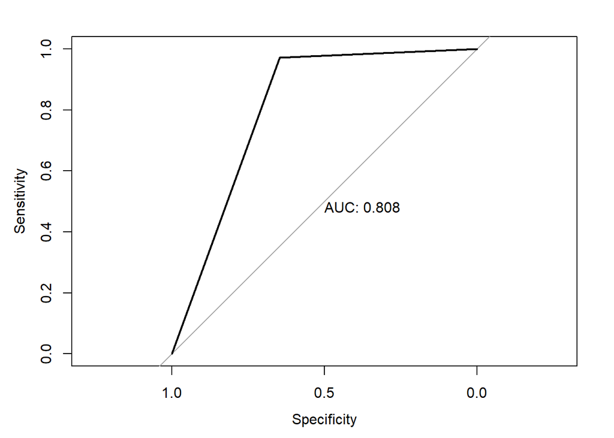

```r
roc_lr2 = roc(test$label, pred1, plot=TRUE, print.auc=TRUE)
```

#### 의사결정나무

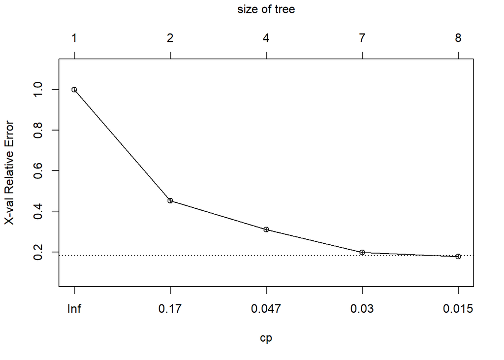

```r
mt = rpart(class ~., data=train.smote, method = "class")
plotcp(mt)
```

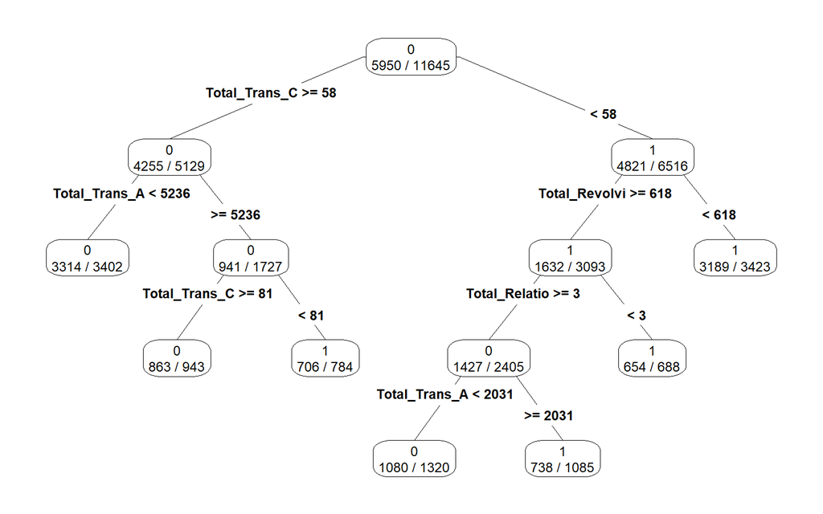

```r
mt_prune = prune(mt,cp=0.036)
library(rpart.plot)
prp(mt_prune, type = 4, extra = 2)
```

```r
printcp(mt_prune)
```

```
##
## Classification tree:
## rpart(formula = class ~ ., data = train.smote, method = "class")
##
## Variables actually used in tree construction:
## [1] Total_Relationship_Count Total_Revolving_Bal      Total_Trans_Amt
## [4] Total_Trans_Ct
##
## Root node error: 5695/11645 = 0.48905
##
## n= 11645
##
##         CP nsplit rel error  xerror      xstd
## 1 0.548903      0   1.00000 1.00000 0.0094720
## 2 0.055136      1   0.45110 0.45285 0.0078681
## 3 0.039421      3   0.34083 0.31010 0.0067965
## 4 0.036000      6   0.19333 0.19701 0.0055912
```

```r
mt_prune$variable.importance
```

```
##           Total_Trans_Ct          Total_Trans_Amt      Total_Revolving_Bal
##               2710.96120               2575.30921                958.12462
##      Total_Ct_Chng_Q4_Q1    Avg_Utilization_Ratio Total_Relationship_Count
##                819.20951                701.09546                637.18638
##    Contacts_Count_12_mon          Avg_Open_To_Buy   Months_Inactive_12_mon
##                342.08966                272.87662                200.33118
##             Credit_Limit     Total_Amt_Chng_Q4_Q1           Marital_Status
##                194.38195                193.31805                 79.05158
##                   Gender            Card_Category
##                 68.43206                 61.59815
```

```r
tree.p = predict(mt_prune, test, type = "class")
cmt = confusionMatrix(tree.p, as.factor(test$label), positive ="1")
round(cmt$byClass["F1"], 4)
```

```
##     F1
## 0.6886
```

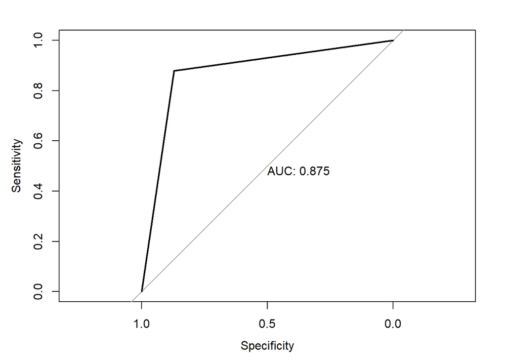

```r
test$tp1= tree.p
roc_t= roc(response= test$label, predictor = factor(test$tp1, ordered=TRUE), plot=TRUE, print.auc=TRUE)
```

#### 랜덤포레스트

```r
trControl <- trainControl(method = "cv",
    number = 10,
    search = "grid")
```

```r
set.seed(1234)
rf1 = train(class ~ .,data=train.smote, method="rf",metric ="Accuracy",trControl = trControl)
print(rf1)
```

```
## Random Forest
##
## 11645 samples
##    19 predictor
##     2 classes: '0', '1'
##
## No pre-processing
## Resampling: Cross-Validated (10 fold)
## Summary of sample sizes: 10480, 10480, 10480, 10480, 10481, 10480, ...
## Resampling results across tuning parameters:
##
##   mtry  Accuracy   Kappa
##    2    0.9788747  0.9577293
##   10    0.9785310  0.9570515
##   19    0.9726922  0.9453732
##
## Accuracy was used to select the optimal model using the largest value.
## The final value used for the model was mtry = 2.
```

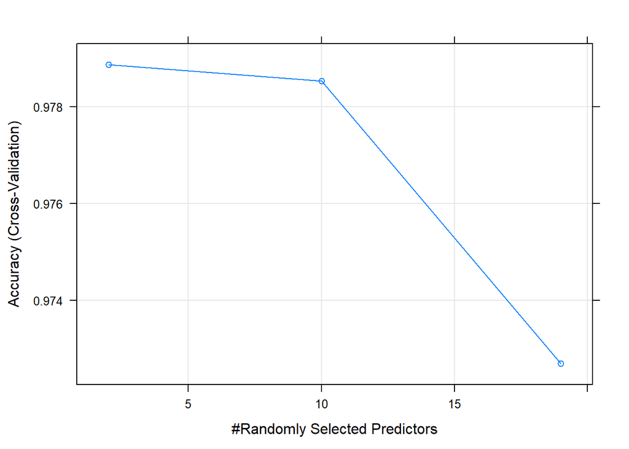

```r
plot(rf1)
```

```r
varImp(rf1)
```

```
## rf variable importance
##
##                          Overall
## Total_Trans_Ct           100.000
## Total_Trans_Amt           97.583
## Total_Revolving_Bal       59.558
## Total_Ct_Chng_Q4_Q1       49.393
## Months_Inactive_12_mon    43.257
## Avg_Utilization_Ratio     37.455
## Contacts_Count_12_mon     37.392
## Total_Relationship_Count  34.144
## Total_Amt_Chng_Q4_Q1      24.629
## Gender                    18.200
## Marital_Status            17.780
## Credit_Limit              15.856
## Avg_Open_To_Buy           15.817
## Customer_Age              14.065
## Education_Level           12.727
## Dependent_count           11.388
## Months_on_book            10.844
## Income_Category            8.906
## Card_Category              0.000
```

```r
rfpred = predict(rf1, test)
cmrf = confusionMatrix(rfpred, as.factor(test$label), positive="1"); cmrf
```

```
## Confusion Matrix and Statistics
##
##           Reference
## Prediction    0    1
##          0 2497   98
##          1   53  390
##
##                Accuracy : 0.9503
##                  95% CI : (0.942, 0.9578)
##     No Information Rate : 0.8394
##     P-Value [Acc > NIR] : < 2.2e-16
##
##                   Kappa : 0.8085
##
##  Mcnemar's Test P-Value : 0.0003427
##
##             Sensitivity : 0.7992
##             Specificity : 0.9792
##          Pos Pred Value : 0.8804
##          Neg Pred Value : 0.9622
##              Prevalence : 0.1606
##          Detection Rate : 0.1284
##    Detection Prevalence : 0.1458
##       Balanced Accuracy : 0.8892
##
##        'Positive' Class : 1
##
```

```r
round(cmrf$byClass["F1"], 4)
```

```
##     F1
## 0.8378
```

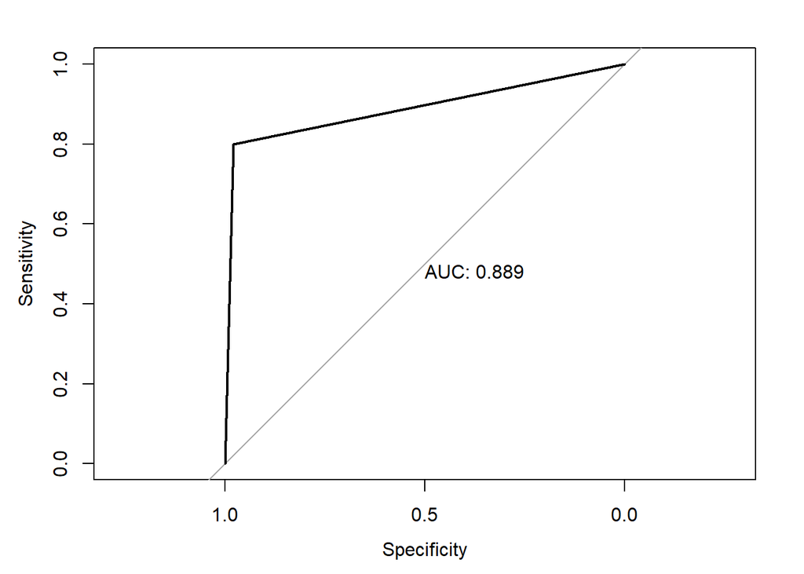

```r
test$rfp= rfpred
roc_rf= roc(response= test$label, predictor = factor(test$rfp, ordered=TRUE), plot=TRUE, print.auc=TRUE)
```